# Script

```python
import numpy as np
#!pip install pandas
import pandas as pd
#!pip install matplotlib
import matplotlib.pyplot as plt
#!pip install seaborn
import seaborn as sns
#!pip install sklearn
from sklearn.linear_model import LinearRegression

import warnings
warnings.filterwarnings('ignore') # ignore warnings messages in iPython

import os # os functions for files/directory manipulation
from scipy.stats import norm
from scipy.special import boxcox1p
from scipy.stats import boxcox_normmax # for skewness
from sklearn.preprocessing import StandardScaler
from scipy import stats
from IPython.display import display, Image
```

```python
data=pd.read_csv("ObesityDataSet_raw_and_data_sinthetic.csv")
data.head(20)
```

|  | Gender | Age | Height | Weight | family_history_with_overweight | FAVC | FCVC | NCP | CAEC | SMOKE | CH2O | SCC | FAF | TUE | CALC | MTRANS | NObeyesdad |
| --- | --- | --- | --- | --- | --- | --- | --- | --- | --- | --- | --- | --- | --- | --- | --- | --- | --- |
| 0 | Female | 21.0 | 1.62 | 64.0 | yes | no | 2.0 | 3.0 | Sometimes | no | 2.0 | no | 0.0 | 1.0 | no | Public_Transportation | Normal_Weight |
| 1 | Female | 21.0 | 1.52 | 56.0 | yes | no | 3.0 | 3.0 | Sometimes | yes | 3.0 | yes | 3.0 | 0.0 | Sometimes | Public_Transportation | Normal_Weight |
| 2 | Male | 23.0 | 1.80 | 77.0 | yes | no | 2.0 | 3.0 | Sometimes | no | 2.0 | no | 2.0 | 1.0 | Frequently | Public_Transportation | Normal_Weight |
| 3 | Male | 27.0 | 1.80 | 87.0 | no | no | 3.0 | 3.0 | Sometimes | no | 2.0 | no | 2.0 | 0.0 | Frequently | Walking | Overweight_Level_I |
| 4 | Male | 22.0 | 1.78 | 89.8 | no | no | 2.0 | 1.0 | Sometimes | no | 2.0 | no | 0.0 | 0.0 | Sometimes | Public_Transportation | Overweight_Level_II |
| 5 | Male | 29.0 | 1.62 | 53.0 | no | yes | 2.0 | 3.0 | Sometimes | no | 2.0 | no | 0.0 | 0.0 | Sometimes | Automobile | Normal_Weight |
| 6 | Female | 23.0 | 1.50 | 55.0 | yes | yes | 3.0 | 3.0 | Sometimes | no | 2.0 | no | 1.0 | 0.0 | Sometimes | Motorbike | Normal_Weight |
| 7 | Male | 22.0 | 1.64 | 53.0 | no | no | 2.0 | 3.0 | Sometimes | no | 2.0 | no | 3.0 | 0.0 | Sometimes | Public_Transportation | Normal_Weight |
| 8 | Male | 24.0 | 1.78 | 64.0 | yes | yes | 3.0 | 3.0 | Sometimes | no | 2.0 | no | 1.0 | 1.0 | Frequently | Public_Transportation | Normal_Weight |
| 9 | Male | 22.0 | 1.72 | 68.0 | yes | yes | 2.0 | 3.0 | Sometimes | no | 2.0 | no | 1.0 | 1.0 | no | Public_Transportation | Normal_Weight |
| 10 | Male | 26.0 | 1.85 | 105.0 | yes | yes | 3.0 | 3.0 | Frequently | no | 3.0 | no | 2.0 | 2.0 | Sometimes | Public_Transportation | Obesity_Type_I |
| 11 | Female | 21.0 | 1.72 | 80.0 | yes | yes | 2.0 | 3.0 | Frequently | no | 2.0 | yes | 2.0 | 1.0 | Sometimes | Public_Transportation | Overweight_Level_II |
| 12 | Male | 22.0 | 1.65 | 56.0 | no | no | 3.0 | 3.0 | Sometimes | no | 3.0 | no | 2.0 | 0.0 | Sometimes | Public_Transportation | Normal_Weight |
| 13 | Male | 41.0 | 1.80 | 99.0 | no | yes | 2.0 | 3.0 | Sometimes | no | 2.0 | no | 2.0 | 1.0 | Frequently | Automobile | Obesity_Type_I |
| 14 | Male | 23.0 | 1.77 | 60.0 | yes | yes | 3.0 | 1.0 | Sometimes | no | 1.0 | no | 1.0 | 1.0 | Sometimes | Public_Transportation | Normal_Weight |
| 15 | Female | 22.0 | 1.70 | 66.0 | yes | no | 3.0 | 3.0 | Always | no | 2.0 | yes | 2.0 | 1.0 | Sometimes | Public_Transportation | Normal_Weight |
| 16 | Male | 27.0 | 1.93 | 102.0 | yes | yes | 2.0 | 1.0 | Sometimes | no | 1.0 | no | 1.0 | 0.0 | Sometimes | Public_Transportation | Overweight_Level_II |
| 17 | Female | 29.0 | 1.53 | 78.0 | no | yes | 2.0 | 1.0 | Sometimes | no | 2.0 | no | 0.0 | 0.0 | no | Automobile | Obesity_Type_I |
| 18 | Female | 30.0 | 1.71 | 82.0 | yes | yes | 3.0 | 4.0 | Frequently | yes | 1.0 | no | 0.0 | 0.0 | no | Automobile | Overweight_Level_II |
| 19 | Female | 23.0 | 1.65 | 70.0 | yes | no | 2.0 | 1.0 | Sometimes | no | 2.0 | no | 0.0 | 0.0 | Sometimes | Public_Transportation | Overweight_Level_I |

```python
#The ARFF file has glitched strings

#from scipy.io import arff

#data = arff.loadarff('ObesityDataSet_raw_and_data_sinthetic.arff')
#df = pd.DataFrame(data[0])

#df.head()
```

[output not shown]

# Data Set Information :

This dataset include data for the estimation of obesity levels in individuals from the countries of Mexico, Peru and Colombia, based on their eating habits and physical condition. The data contains 17 attributes and 2111 records, the records are labeled with the class variable NObesity (Obesity Level), that allows classification of the data using the values of Insufficient Weight, Normal Weight, Overweight Level I, Overweight Level II, Obesity Type I, Obesity Type II and Obesity Type III. 77% of the data was generated synthetically using the Weka tool and the SMOTE filter, 23% of the data was collected directly from users through a web platform.

From the cited paper "Palechor, F. M., & de la Hoz Manotas, A. (2019). Dataset for estimation of obesity levels based on eating habits and physical condition in individuals from Colombia, Peru and Mexico. Data in Brief, 104344" we can infer the meaning of the colomn abbreviations : https://www.sciencedirect.com/science/article/pii/S2352340919306985?via%3Dihub

| Column name | Description |
| --- | --- |
| Gender | Self explanatory |
| Age | Self explanatory |
| Height | Self explanatory |
| Weight | Self explanatory |
| family_history_with_overweight | Self explanatory |
| FAVC | Eats caloric food frequently |
| FCVC | Frequency eating vegetables |
| NCP | number of meals |
| CAEC | eats btween meals |
| SMOKE | Self explanatory |
| CH2O | frequency drinking water |
| SCC | frequency monitors calories |
| FAF | phys. activity frequency |
| TUE | time using tech. devices |
| CALC | frequency drinking alcohol |
| MTRANS | Usual transportation |
| NObeyesdad | Obesity level |

# Variable creation

We create a new variable called MBI to calculate correlations

```python
MBI=data['Weight']/(data['Height']**2)
data['MBI']=MBI
data
```

|  | Gender | Age | Height | Weight | family_history_with_overweight | FAVC | FCVC | NCP | CAEC | SMOKE | CH2O | SCC | FAF | TUE | CALC | MTRANS | NObeyesdad | MBI |
| --- | --- | --- | --- | --- | --- | --- | --- | --- | --- | --- | --- | --- | --- | --- | --- | --- | --- | --- |
| 0 | Female | 21.000000 | 1.620000 | 64.000000 | yes | no | 2.0 | 3.0 | Sometimes | no | 2.000000 | no | 0.000000 | 1.000000 | no | Public_Transportation | Normal_Weight | 24.386526 |
| 1 | Female | 21.000000 | 1.520000 | 56.000000 | yes | no | 3.0 | 3.0 | Sometimes | yes | 3.000000 | yes | 3.000000 | 0.000000 | Sometimes | Public_Transportation | Normal_Weight | 24.238227 |
| 2 | Male | 23.000000 | 1.800000 | 77.000000 | yes | no | 2.0 | 3.0 | Sometimes | no | 2.000000 | no | 2.000000 | 1.000000 | Frequently | Public_Transportation | Normal_Weight | 23.765432 |
| 3 | Male | 27.000000 | 1.800000 | 87.000000 | no | no | 3.0 | 3.0 | Sometimes | no | 2.000000 | no | 2.000000 | 0.000000 | Frequently | Walking | Overweight_Level_I | 26.851852 |
| 4 | Male | 22.000000 | 1.780000 | 89.800000 | no | no | 2.0 | 1.0 | Sometimes | no | 2.000000 | no | 0.000000 | 0.000000 | Sometimes | Public_Transportation | Overweight_Level_II | 28.342381 |
| ... | ... | ... | ... | ... | ... | ... | ... | ... | ... | ... | ... | ... | ... | ... | ... | ... | ... | ... |
| 2106 | Female | 20.976842 | 1.710730 | 131.408528 | yes | yes | 3.0 | 3.0 | Sometimes | no | 1.728139 | no | 1.676269 | 0.906247 | Sometimes | Public_Transportation | Obesity_Type_III | 44.901475 |
| 2107 | Female | 21.982942 | 1.748584 | 133.742943 | yes | yes | 3.0 | 3.0 | Sometimes | no | 2.005130 | no | 1.341390 | 0.599270 | Sometimes | Public_Transportation | Obesity_Type_III | 43.741923 |
| 2108 | Female | 22.524036 | 1.752206 | 133.689352 | yes | yes | 3.0 | 3.0 | Sometimes | no | 2.054193 | no | 1.414209 | 0.646288 | Sometimes | Public_Transportation | Obesity_Type_III | 43.543817 |
| 2109 | Female | 24.361936 | 1.739450 | 133.346641 | yes | yes | 3.0 | 3.0 | Sometimes | no | 2.852339 | no | 1.139107 | 0.586035 | Sometimes | Public_Transportation | Obesity_Type_III | 44.071535 |
| 2110 | Female | 23.664709 | 1.738836 | 133.472641 | yes | yes | 3.0 | 3.0 | Sometimes | no | 2.863513 | no | 1.026452 | 0.714137 | Sometimes | Public_Transportation | Obesity_Type_III | 44.144338 |

2111 rows × 18 columns

# Exploratory Data Analysis :

```python
data.dtypes
```

```
Gender                             object
Age                               float64
Height                            float64
Weight                            float64
family_history_with_overweight     object
FAVC                               object
FCVC                              float64
NCP                               float64
CAEC                               object
SMOKE                              object
CH2O                              float64
SCC                                object
FAF                               float64
TUE                               float64
CALC                               object
MTRANS                             object
NObeyesdad                         object
MBI                               float64
dtype: object
```

```python
data.describe().T
```

|  | count | mean | std | min | 25% | 50% | 75% | max |
| --- | --- | --- | --- | --- | --- | --- | --- | --- |
| Age | 2111.0 | 24.312600 | 6.345968 | 14.000000 | 19.947192 | 22.777890 | 26.000000 | 61.000000 |
| Height | 2111.0 | 1.701677 | 0.093305 | 1.450000 | 1.630000 | 1.700499 | 1.768464 | 1.980000 |
| Weight | 2111.0 | 86.586058 | 26.191172 | 39.000000 | 65.473343 | 83.000000 | 107.430682 | 173.000000 |
| FCVC | 2111.0 | 2.419043 | 0.533927 | 1.000000 | 2.000000 | 2.385502 | 3.000000 | 3.000000 |
| NCP | 2111.0 | 2.685628 | 0.778039 | 1.000000 | 2.658738 | 3.000000 | 3.000000 | 4.000000 |
| CH2O | 2111.0 | 2.008011 | 0.612953 | 1.000000 | 1.584812 | 2.000000 | 2.477420 | 3.000000 |
| FAF | 2111.0 | 1.010298 | 0.850592 | 0.000000 | 0.124505 | 1.000000 | 1.666678 | 3.000000 |
| TUE | 2111.0 | 0.657866 | 0.608927 | 0.000000 | 0.000000 | 0.625350 | 1.000000 | 2.000000 |
| MBI | 2111.0 | 29.700159 | 8.011337 | 12.998685 | 24.325802 | 28.719089 | 36.016501 | 50.811753 |

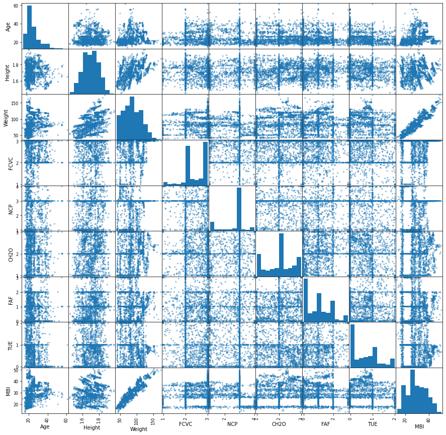

```python
visu= pd.plotting.scatter_matrix(data, figsize=(15,15))
```

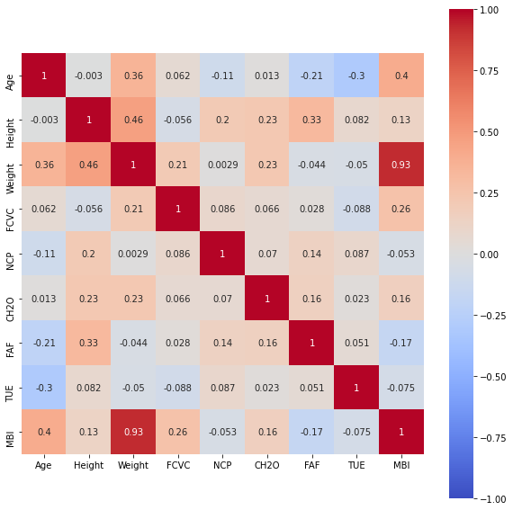

```python
plt.figure(figsize=(10,10))
sns.heatmap(data.corr("spearman"),
            vmin=-1, vmax=1,
            cmap='coolwarm',
            annot=True,
            square=True);
```

# Simple Linear Regression

```python
# Trying a simple linear regression on vegetable consumption
lmveg=LinearRegression()
vegetables=data.FCVC.to_numpy().reshape(-1, 1)
lmveg.fit(vegetables, data.MBI)

# Doing the same with age
lmage=LinearRegression()
age=data.Age.to_numpy().reshape(-1, 1)
lmage.fit(age, data.MBI)
```

```
LinearRegression()
```

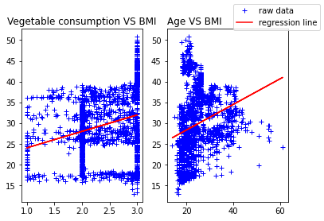

```python
# plotting the vegetable plot
fig, axs = plt.subplots(1, 2)
axs[0].plot(vegetables, data.MBI, '+', color='b', label='raw data')
axs[0].plot(vegetables, lmveg.predict(vegetables), color='r', label='regression line')
axs[0].set_title('Vegetable consumption VS BMI')
fig.legend()


#plotting the age plot
axs[1].plot(age, data.MBI, '+', color='b', label='raw data')
axs[1].plot(age, lmage.predict(age), color='r', label='regression line')
axs[1].set_title('Age VS BMI', loc='left')
```

```python
from sklearn.metrics import r2_score
print(r2_score(data.MBI, lmage.predict(age)))
print(r2_score(data.MBI, lmveg.predict(vegetables)))

# sans surprise, le r² est très mauvais.
```

```
0.05961562727430303
0.06951176426395012
```

# Multiple linear regression :

```python
x=np.concatenate((age, vegetables), axis=1)
lm=LinearRegression()
lm.fit(x, data.MBI)

print(r2_score(data.MBI, lm.predict(x)))
#Le r² est meilleur
```

```
0.12706370053989313
```

```python
#adding all avilable variables to the model

meals=data.NCP.to_numpy().reshape(-1, 1)
activ=data.FAF.to_numpy().reshape(-1, 1)
devices=data.TUE.to_numpy().reshape(-1, 1)
water=data.CH2O.to_numpy().reshape(-1, 1)

x=np.concatenate((age, vegetables, meals, activ, devices, water), axis=1)
lm=LinearRegression()
lm.fit(x, data.MBI)

print(r2_score(data.MBI, lm.predict(x)))
#Le r² est bien meilleur
```

```
0.17917411924373794
```

# Polynomial Regression :

```python
# testing on the whole dataset
from sklearn.preprocessing import PolynomialFeatures
from sklearn.pipeline import make_pipeline
from sklearn.linear_model import Ridge
poly=make_pipeline(PolynomialFeatures(4), Ridge())
poly.fit(x, data.MBI)
print(r2_score(data.MBI, poly.predict(x)))
```

```
0.5909123548804128
```

```python
#splitting the dataset
dftest=data.iloc[:1500,:]
dftrain=data.iloc[:1501,:]

#selecting the right features
age=dftest.Age.to_numpy().reshape(-1, 1)
vegetables=dftest.FCVC.to_numpy().reshape(-1, 1)
meals=dftest.NCP.to_numpy().reshape(-1, 1)
activ=dftest.FAF.to_numpy().reshape(-1, 1)
devices=dftest.TUE.to_numpy().reshape(-1, 1)
water=dftest.CH2O.to_numpy().reshape(-1, 1)

xtest=np.concatenate((age, vegetables, meals, activ, devices, water), axis=1)

age=dftrain.Age.to_numpy().reshape(-1, 1)
vegetables=dftrain.FCVC.to_numpy().reshape(-1, 1)
meals=dftrain.NCP.to_numpy().reshape(-1, 1)
activ=dftrain.FAF.to_numpy().reshape(-1, 1)
devices=dftrain.TUE.to_numpy().reshape(-1, 1)
water=dftrain.CH2O.to_numpy().reshape(-1, 1)

xtrain=np.concatenate((age, vegetables, meals, activ, devices, water), axis=1)
```

# Training, evaluating

## Multiple Linear Regression

```python
xtest
```

```
array([[21.      ,  2.      ,  3.      ,  0.      ,  1.      ,  2.      ],
       [21.      ,  3.      ,  3.      ,  3.      ,  0.      ,  3.      ],
       [23.      ,  2.      ,  3.      ,  2.      ,  1.      ,  2.      ],
       ...,
       [18.      ,  2.818502,  3.      ,  1.492967,  0.      ,  1.991251],
       [18.      ,  2.081238,  3.      ,  1.17177 ,  0.      ,  1.18363 ],
       [23.246702,  1.368978,  3.      ,  0.104707,  0.22183 ,  1.953152]])
```

```python
lm=LinearRegression
lm.fit(xtrain, dftrain.MBI)
print('r² score :', r2_score(dftest.MBI, lm.predict(xtest)))
```

[output not shown]

## Polynomial Regression

```python
for deg in range(2,8):
    poly=make_pipeline(PolynomialFeatures(deg), Ridge())
    poly.fit(xtrain, dftrain.MBI)
    print('r² score for degree', deg, ' :', r2_score(dftest.MBI, poly.predict(xtest)))
```

```
r² score for degree 2  : 0.29914294439952116
r² score for degree 3  : 0.36620604700465076
r² score for degree 4  : 0.45107032359982957
r² score for degree 5  : 0.5816602568208353
r² score for degree 6  : 0.699646460213473
r² score for degree 7  : 0.3715665526502965
```